# Final Project-Analysis of companies in Alderaan and Bespin

Batillat Kim , Lucas Axel , Li Judith

2022-11-19

## Introcduction

One of the most common tasks in engineering management is to analyse vast quantities of data to understand what’s happening and taking optimal decisions based on our findings.

Laura, the new CEO of The Institute of Equality, Diversity and Inclusiveness in region Corellia has contacted us to discuss what is happening in two cities (Alderaan and Bespin). After the hard work of data collection, the new CEO has been able to collect information about the selection processes over two months. This information contains data on the candidates and their environment, the job position, the recruiting company and its environment, and whether the candidate finally received a call back on his or her application.

Laura is concerned about several issues. She believes that certain companies may be biased towards some candidates because of their gender, race, or even background they come from. Laura has therefore asked us to carry out an exploratory analysis.

## Setup the software

The software used for the development of the study and the writing of the report is R. The first step is to load the libraries :

```r
library(tidyverse)
library(tidymodels)
library(dplyr)
library(janitor)
library(ggplot2)
library(reshape2)
library(gridExtra)
library(corrplot)
# logistic regression
library(data.table)
library(ggcorrplot)
library(mice)
library(VIM)
library(caTools)
library(ROCR)
# tree
library(rpart)
library(rpart.plot)
library(rattle)
```

### Importing data

We are going to load the data set and check that everything is correct. Instead of using a standard R data.frame, we have decided to use a tibble because this makes it much easier to work with large data.

```r
mydata=read.csv("data_set.csv")%>%tibble()
```

In this set data of data, we have information about : candidate’s resume , if the candidate was pre-selected or not , candidate’s context and environment, the job position,the employer and the employer’s context and environment .

We are going to check if we have loaded all information from the file.

```r
nrow(mydata)
```

```
## [1] 4870
```

```r
ncol(mydata)
```

```
## [1] 58
```

There are 4870 rows and 58 columns in the data set. The right numbers according to the data source. Now, we are going to check if the type of the variables is the right one.

```r
str(mydata)
```

[output not shown]

We can see that the type of the variables fits to the expected one. Now, we are going to check if the data at the beginning or at the end of the data set is right.

```r
mydata%>%head(3)
```

```
## # A tibble: 3 × 58
##       X education n_jobs years_exp honors volunt…¹ milit…² occup…³ work_…⁴ email
##   <int>     <int>  <int>     <int>  <int>    <int>   <int>   <int>   <int> <int>
## 1     1         4      2         6      0        0       0       1       0     0
## 2     2         3      3         6      0        1       1       6       1     1
## 3     3         4      1         6      0        0       0       1       1     0
## # … with 48 more variables: computer_skills <int>, special_skills <int>,
## #   first_name <chr>, sex <chr>, race <chr>, h <int>, l <int>, call <int>,
## #   city <chr>, kind <chr>, ad_id <int>, frac_black <dbl>, frac_white <dbl>,
## #   l_med_hh_inc <dbl>, frac_dropout <dbl>, frac_colp <dbl>, l_inc <dbl>,
## #   col <int>, exp_min_req <chr>, school_req <chr>, parent_sales <dbl>,
## #   parent_emp <dbl>, branch_sales <dbl>, branch_emp <dbl>,
## #   frac_black_emp_zip <dbl>, frac_white_emp_zip <dbl>, …
```

```r
mydata%>%tail(3)
```

```
## # A tibble: 3 × 58
##       X education n_jobs years_exp honors volunt…¹ milit…² occup…³ work_…⁴ email
##   <int>     <int>  <int>     <int>  <int>    <int>   <int>   <int>   <int> <int>
## 1  4868         4      6         8      0        1       0       1       1     1
## 2  4869         4      4         2      0        1       1       4       1     1
## 3  4870         4      3         7      0        0       0       4       0     0
## # … with 48 more variables: computer_skills <int>, special_skills <int>,
## #   first_name <chr>, sex <chr>, race <chr>, h <int>, l <int>, call <int>,
## #   city <chr>, kind <chr>, ad_id <int>, frac_black <dbl>, frac_white <dbl>,
## #   l_med_hh_inc <dbl>, frac_dropout <dbl>, frac_colp <dbl>, l_inc <dbl>,
## #   col <int>, exp_min_req <chr>, school_req <chr>, parent_sales <dbl>,
## #   parent_emp <dbl>, branch_sales <dbl>, branch_emp <dbl>,
## #   frac_black_emp_zip <dbl>, frac_white_emp_zip <dbl>, …
```

Theses cases are right.

## Analysing on pre selected candidates

In order to give an explanation to Laura , let’s analyse we are going to answer this following questions:

#### 1. Observations regarding the candidate’s resume

###### a) How many candidates are pre-selected ?

We have 392 candidates who are pre selected on 4870 candidates.

```r
Preselected=mydata%>%filter(call==1)
nrow(Preselected) # number of pre selected candidates
```

```
## [1] 392
```

```r
mydataCor=mydata%>%select(-(first_name:race))%>%select((education:call))

cormat = round(cor(mydataCor),2) # Calculate the Correlation Matrix
mydataCor_corrMat =melt(cormat) # Reshape the previous matrix
```

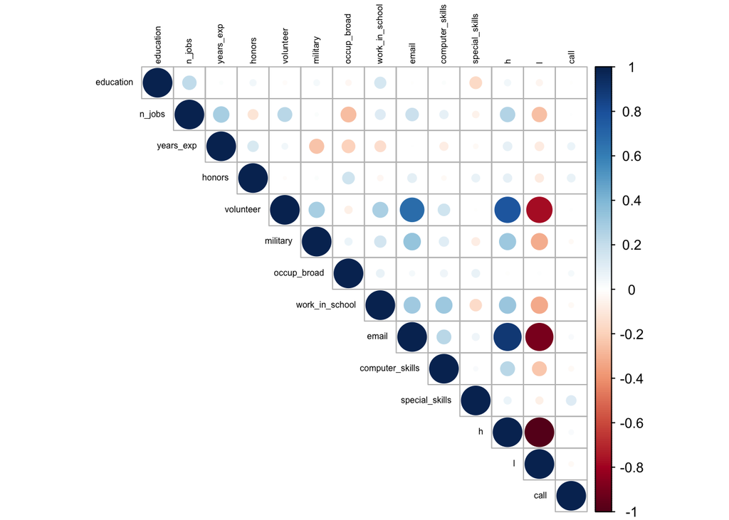

```r
#mydataCor_corrMat
mydataCor_corrMat=cor(as.matrix(na.omit(mydataCor)))
corrplot(mydataCor_corrMat,type="upper",tl.col="black",tl.cex = 0.5)
```

But this correlation are not so strong so let’s study this correlation briefly. As we can see on graphics bellow , the fact to have specials skills or honors don’t influence a lot pre selections. Indeed, we have a consequent number of applicant who was called back without any specials skills or honors.

Concerning the year experiences, there is beginners as well as professionals applicant who was called back. But most of them , have a average of years experience equal to 8 years.

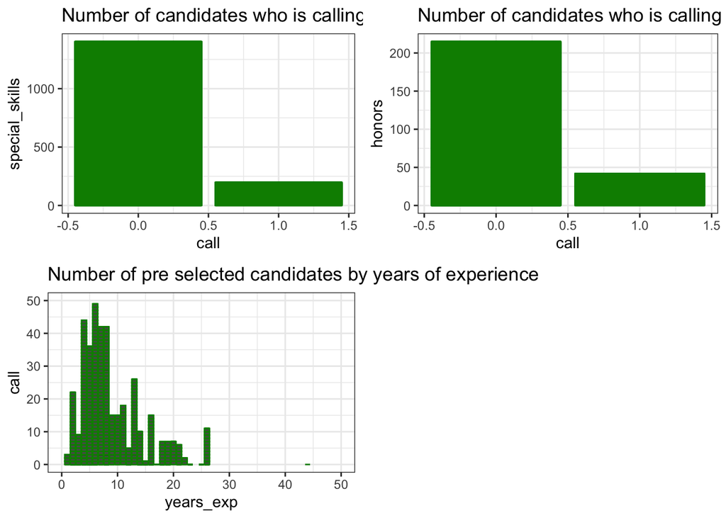

```r
#special_skill
p1=ggplot(mydata, aes(x=call, y=special_skills)) + geom_bar(stat="identity", color="green4")+
  labs(title = "Number of candidates who is calling because of special skills ")+
  theme_bw()
# honors
p2=ggplot(mydata, aes(x=call, y=honors)) + geom_bar(stat="identity", color="green4")+
  labs(title = "Number of candidates who is calling because of honors ")+
  theme_bw()
# years_exp
p3=ggplot(mydata, aes(x=years_exp, y=call)) + geom_bar(stat="identity", color="green4")+
  labs(title = "Number of pre selected candidates by years of experience")+
  scale_y_continuous(limits= c(0, 50)) +
  scale_x_continuous(limits = c(0, 50))+
  theme_bw()
grid.arrange(p1, p2, p3,ncol=2)
```

Let’s see what is the common point on the 392 candidates on their resume who are pre selected regarding their : sex,race and first_name.

###### a) Acoording to Laura believes is their some biasement towards some candidates because of their gender, race or background ?

**analysis on the gender of pre selected candidates**

There is more female pre selected: 309 rather than men: 83 as we can see on the graph bellow :

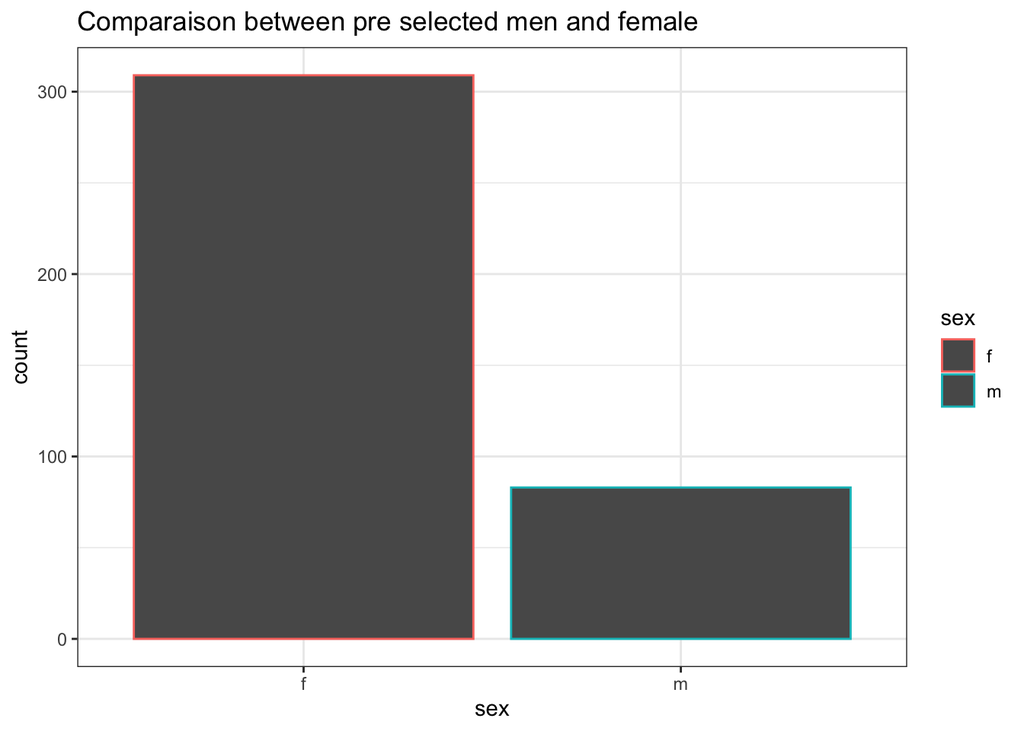

```r
FPreselected=Preselected%>%filter(sex=="f")
MPreselected=Preselected%>%filter(sex=="m")
ggplot(Preselected,aes(sex,group=sex,color=sex))+geom_bar()+labs(title = "Comparaison between pre selected men and female ")+theme_bw()
```

By the same way we can see that on pre selected candidates there is more white people rather than black people between men and women pre selected candidates. And between women , we observe the same case. So, the majority of pre selected candidates are white females . ?

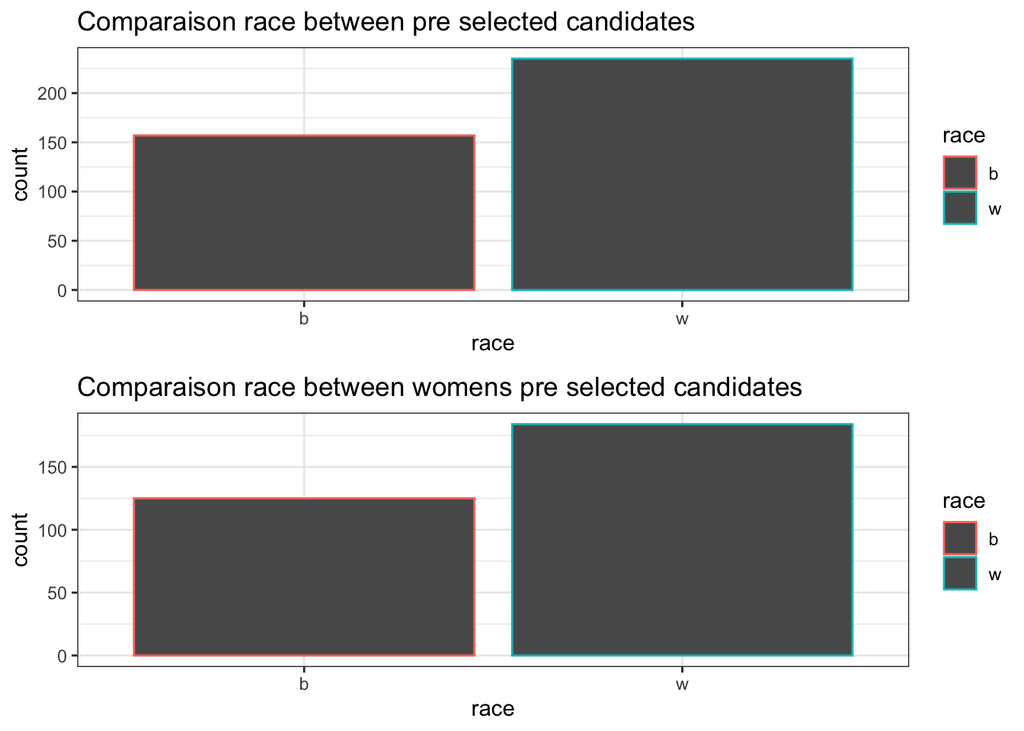

```r
# Comparaison race Pre selected candidates
p4=ggplot(Preselected,aes(race,group=race,color=race))+geom_bar()+labs(title = "Comparaison race between pre selected candidates")+theme_bw()
# Comparaison race Pre selected candidates between women
p5=ggplot(FPreselected,aes(race,group=race,color=race))+geom_bar()+labs(title = "Comparaison race between womens pre selected candidates")+theme_bw()
grid.arrange(p4, p5, ncol=1)
```

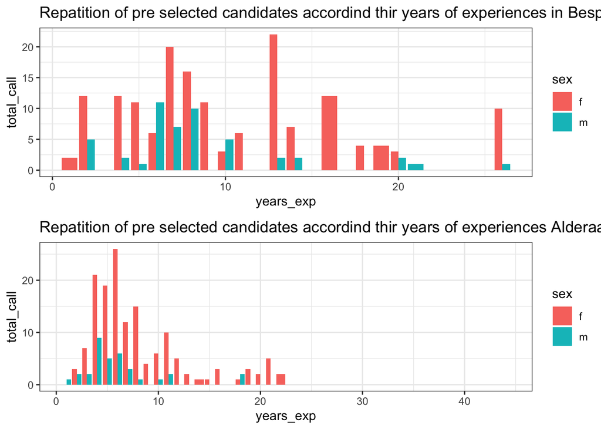

```r
# Genre dans les deux filles années d'expériences appel

dataB=mydata%>%select(city,call,sex,years_exp)%>%filter(city=='b') # city b
dataB=dataB%>%group_by(years_exp,sex)
dataB=dataB%>%summarise(total_call=sum(call))

pB= dataB%>%ggplot(aes(x=years_exp,y=total_call,fill=sex))+geom_bar(stat="identity",position=position_dodge())+theme_bw()+labs(title = "Repatition of pre selected candidates accordind thir years of experiences in Bespin ")

dataC=mydata%>%select(city,call,sex,years_exp)%>%filter(city=='c') # city c
dataC=dataC%>%group_by(years_exp,sex)
dataC=dataC%>%summarise(total_call=sum(call))

pC=dataC%>%ggplot(aes(x=years_exp,y=total_call,fill=sex))+geom_bar(stat="identity",position=position_dodge())+theme_bw()+labs(title = "Repatition of pre selected candidates accordind thir years of experiences Alderaan ")

grid.arrange(pB, pC, ncol=1)
```

**analysis on the race of pre selected candidates**

1-Study of the difference between black and white to the preselection

Before starting, our analysis it’s important to count how many black and whites do we have, to be sure that we compare the same things.

```r
nrow(mydata%>%filter(race=="b"))
```

```
## [1] 2435
```

```r
nrow(mydata%>%filter(race=="w"))
```

```
## [1] 2435
```

We have the same number of blacks and whites persons.

## 1.A study of the education of the different race

**Through this part, we try to study the studies of the different races and to see if there is a race which has a better level of study or not than another one.** **To do this, we are going to carry out a T.Test to see if the study averages are identical.** **H0: The education means are the same at 5%.** **H1: The means are not the same.**

```r
myB<-mydata%>%filter(race=="b")
myW<-mydata%>%filter(race=="w")
## Testing hypothesis
t.test(myB$education, myW$education, alternative = "two.sided", paired = TRUE, var.equal = TRUE, conf.level = 0.95)
```

```
##
##  Paired t-test
##
## data:  myB$education and myW$education
## t = -0.26045, df = 2434, p-value = 0.7945
## alternative hypothesis: true mean difference is not equal to 0
## 95 percent confidence interval:
##  -0.04203215  0.03217589
## sample estimates:
## mean difference
##    -0.004928131
```

**We realize that the “p-value”>0.05 so we can accept H0, so both races have on average the same level of study. We can see it below with this graph, where we have in ordinate the number of students with the levels of study. We can see that they have about the same level of study. So the level of study being the same, it should not be a criterion for differences on the selections.**

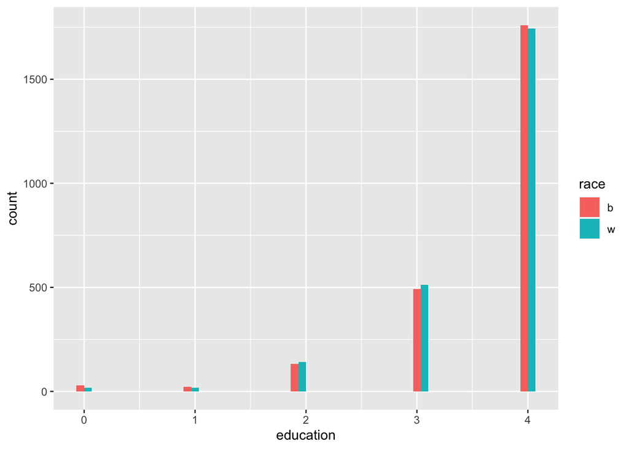

```r
mydata %>% ggplot(aes(x=education, fill=race)) + geom_histogram( position=position_dodge())
```

## 1-B Study of the experience of different race

**Through this part, we try to determine if there is a difference between the number of years of the different breeds. To do this, we will look at whether the number of years of experience and the number of experiences are related. Then, we will look through a T.Test if the average of the experiences of the whites is equal to that of the blacks** **First we will do a regression to see if the number of experiences and the number of years of experience are related.** **For this, we define the following hypotheses.** **H0: the two variables are related** **H1: They are not related**

```r
mtcars03 <- lm(n_jobs ~ years_exp, data=mydata)
summary(mtcars03)
```

```
##
## Call:
## lm(formula = n_jobs ~ years_exp, data = mydata)
##
## Residuals:
##     Min      1Q  Median      3Q     Max
## -3.5765 -0.6028 -0.0896  0.6059  3.5363
##
## Coefficients:
##             Estimate Std. Error t value Pr(>|t|)
## (Intercept) 3.115906   0.030933  100.73   <2e-16 ***
## years_exp   0.069552   0.003317   20.97   <2e-16 ***
## ---
## Signif. codes:  0 '***' 0.001 '**' 0.01 '*' 0.05 '.' 0.1 ' ' 1
##
## Residual standard error: 1.168 on 4868 degrees of freedom
## Multiple R-squared:  0.08283,    Adjusted R-squared:  0.08264
## F-statistic: 439.6 on 1 and 4868 DF,  p-value: < 2.2e-16
```

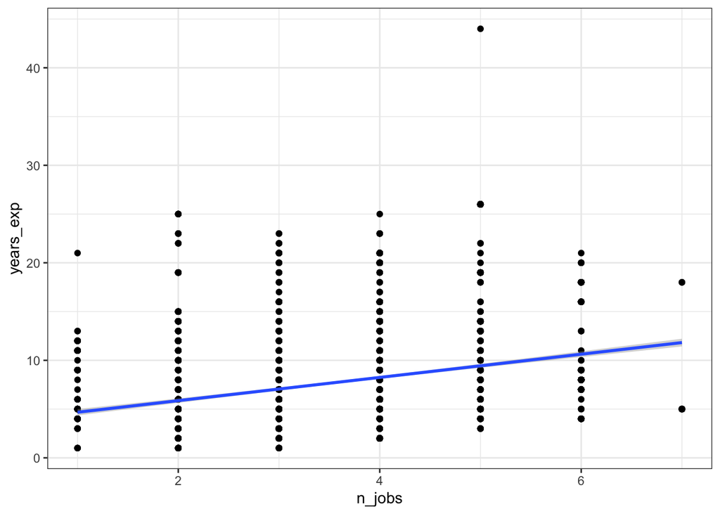

```r
ggplot(mydata, aes(n_jobs, years_exp)) +
  geom_point() +
  geom_smooth(method = "lm") +
  theme_bw()
```

**We see that pr<0.05 so we validate H0 so we can say that the number of experiences and the number of years of experience are linked**

**In order to simplify, we will use only the number of years of experience. In our next test, we will see if the number of years of experience is on average equal for both races.** **Avec:** **H0: The number of experiences means are the same at 5%.** **H1: The number of experiences means are not the same.**

```r
## Testing hypothesis
t.test(myB$years_exp, myW$years_exp, alternative = "two.sided", paired = TRUE, var.equal = TRUE, conf.level = 0.95)
```

```
##
##  Paired t-test
##
## data:  myB$years_exp and myW$years_exp
## t = -0.2082, df = 2434, p-value = 0.8351
## alternative hypothesis: true mean difference is not equal to 0
## 95 percent confidence interval:
##  -0.2781188  0.2247307
## sample estimates:
## mean difference
##     -0.02669405
```

**We realize that the p-value>0.05 so the average of experience of both breeds is the same.** **Also, we can see below that there are also the same repartition in number of jobs for blacks and white. The number of experiments will not be a reason to select more one race or another.**

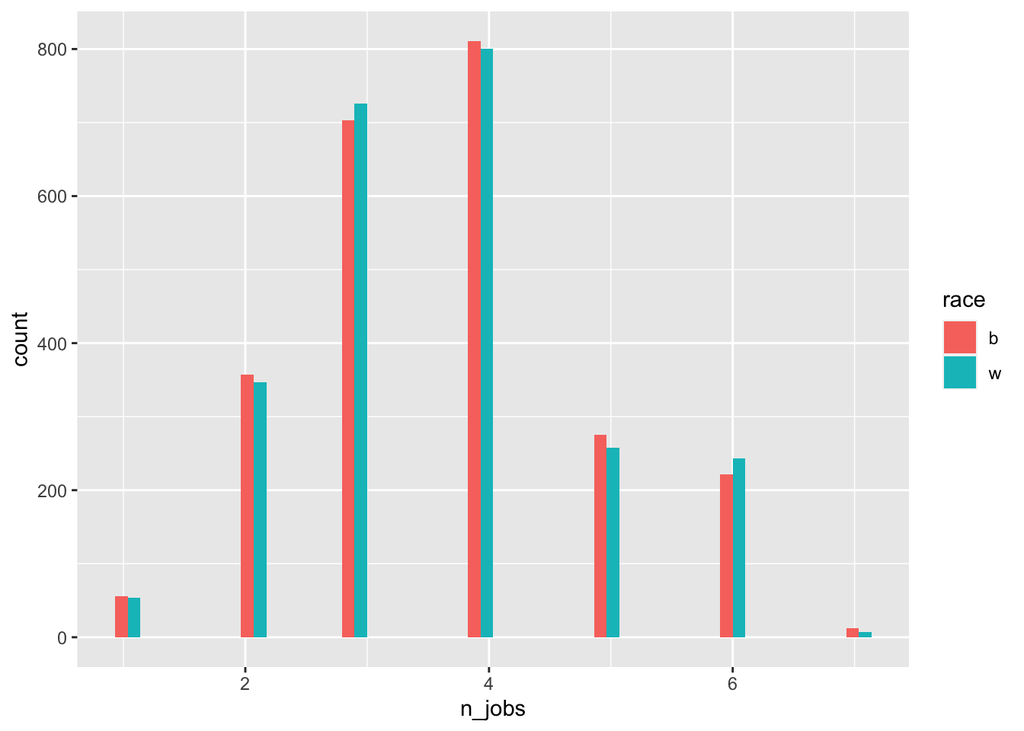

```r
mydata %>% ggplot(aes(x=n_jobs, fill=race)) + geom_histogram( position=position_dodge())
```

## 1-C Repartition of the race per names

**Through this patient, we want to see if a name is carried by a race or if a white and a black can have the same first name.**

```r
myDF1<-data_frame(mydata$first_name,mydata$race,0)
colnames(myDF1)<-c("first_name","race","x")
row<- nrow(mydata)
for (i in 1:row){
  dataD<-mydata %>% filter(first_name==mydata[i,13] & race==mydata[i,15])
  myDF1[i,3]<-nrow(dataD)
}
dataB<-myDF1%>%group_by(first_name,race)%>%summarize(number=mean(x))
```

[figure not shown]

```r
dataB %>% ggplot(aes(x=first_name, y=number, fill=race)) + geom_bar(stat="identity", position=position_dodge())+theme(axis.text.x = element_text(angle=90))
```

## 1-D study of the pre-selected persons

**We want to see if whites are more often pre-selected than blacks.** **For that, we have realized a T.Test with as hypothesis:** **H0: whites are more often called than blacks within 5%.** **H1: it is the opposite of H0**

```r
t.test(myB$call, myW$call, alternative = "greater", paired = FALSE, var.equal = TRUE, conf.level = 0.95)
```

```
##
##  Two Sample t-test
##
## data:  myB$call and myW$call
## t = -4.1147, df = 4868, p-value = 1
## alternative hypothesis: true difference in means is greater than 0
## 95 percent confidence interval:
##  -0.04484043         Inf
## sample estimates:
##  mean of x  mean of y
## 0.06447639 0.09650924
```

**We see that p.Value>0,05 so on average whites are more often pre-selected than blacks. in fact, 9.6% of whites were pre-selected against 6.5% of blacks**

```r
test1<-mydata%>%group_by(education, race)%>%summarise(pre_selected_mean=mean(call))
```

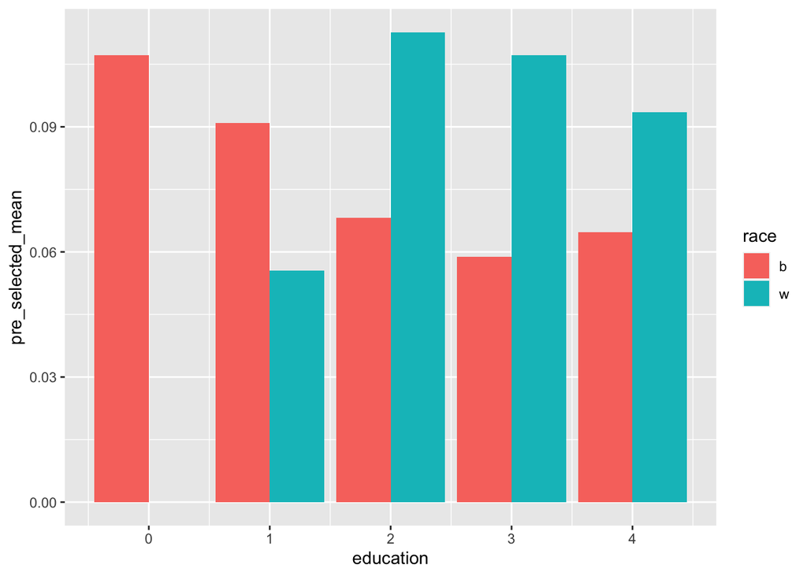

```r
test1 %>% ggplot(aes(x=education, y=pre_selected_mean, fill=race)) + geom_bar(stat="identity", position=position_dodge())
```

**Moreover, when we look at the distribution of the preselected, we realize that blacks are more often selected when they have 0 or 1 of education but then it is very largely the whites who are preselected.**

## 1-E Conclusion

**We realize that whites are more advantaged than blacks. In fact, despite the fact that blacks and whites have the same level of education and the same number of jobs, whites are called much more often. This could be explained by the fact that the first names are either given to whites or blacks, which makes it easier to discriminate.**

**Classification tree**

We work on the selected candidates. At first we make sure to have clean data. We have the frequency of the modalities for the qualitative variables and some key figures for the quantitative variables.

```r
data0=mydata%>%filter(call==1)
data0=as.data.frame(data0)

for (i in c("sex","race","city","kind","ownership","school_req","exp_min_req","call"))
{
  data0[,i]=as.factor(data0[,i])
}
data0=select(data0,-c(X,first_name)) # not need
#summary(data0)
#str(data0)
```

```r
# splip into train and test data
split=sample.split(data0$race,SplitRatio=0.75)
cTrain=subset(data0,split == TRUE)
cTest=subset(data0,split == FALSE)
```

We will now build the tree and prune it.

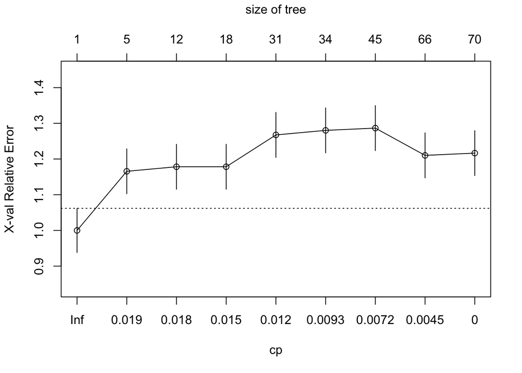

```r
#Construction of the tree
tree1=rpart(race ~ ., data = data0, method = "class", control=rpart.control(minsplit=5,cp=0))
# minimization of the errors
plotcp(tree1)
```

```r
##optimal cp
print(tree1$cptable[which.min(tree1$cptable[,4]),1])
```

```
## [1] 0.01910828
```

[figure not shown]

```r
#Pruning the tree with the optimal cp
tree1.opt=prune(tree1,cp=tree1$cptablex[which.min(tree1$cptable[,4]),1])
# tree optimal
prp(tree1.opt,extra=1)
```

[figure not shown]

```r
fancyRpartPlot(tree1.opt)
```

After obtaining our tree, we must test and validate the results with the test sample

```r
#Model prediction on test data
cTest.predict=predict(tree1.opt,newdata=cTest,type = "class")
#Confusion Matrix
mc=table(cTest$race,cTest.predict)
mc
```

```
##    cTest.predict
##      b  w
##   b 32  7
##   w  3 56
```

```r
#Classification error
1.0-(mc[1,1]+mc[2,2])/sum(mc)
```

```
## [1] 0.1020408
```

```r
#Prediction rate
mc[2,2]/sum(mc[2,])
```

```
## [1] 0.9491525
```

## References

[1] Wickham H, Averick M, Bryan J, Chang W, McGowan LD, François R, Grolemund G, Hayes A, Henry L, Hester J, Kuhn M, Pedersen TL, Miller E, Bache SM, Müller K, Ooms J, Robinson D, Seidel DP, Spinu V, Takahashi K, Vaughan D, Wilke C, Woo K, Yutani H (2019). “Welcome to the tidyverse.” *Journal of Open Source Software*, *4*(43), 1686. doi:10.21105/joss.01686 https://doi.org/10.21105/joss.01686.